# Web Scraping and Data Wrangling StackOverflow Tags

Ali Salahi

### Preliminary

This project was particularly counter-intuitive; it was really easy to think you were pulling all the information you wanted with your xpaths, then 5 pages later all your top-level functions are giving errors. Firstly, I will summate my xpaths I used to pull the information requested (poster, time, title, reputation, views, answers, score, url, id, and tags). All, except for Username, Reputation, and Tags were rather straight-forward and did not require too much iteration. I wrote a mini-function for each piece of information requested per post per page (I used 50 posts/page).

My xpath writing ability was partially improved when a Ph.D. candidate in the Stats Department showed how to utilize developer tools on Firefox to allow us to jump to that part of the parsed html, and this is how I selected which text or attribute to pull from the html and subsequently how to write the xpath.

I then attempted to answer a few questions and run some visualizations with the data I scraped.

My code, in its entirety, is attached at the bottom of this report under ‘Code Appendix’.

### XML’s and XPaths

For time, I used, `"//div[@class = 'user-action-time']/span/@title"`, this was rather direct, and well formatted, it was especially to be able to pull the attribute directly.

For the post title, I used, `"//div[@class = 'summary']/h3/a[@class = 'question-hyperlink']/text()"`. This allowed me to directly pull the text hyperlinked to the question page.

For views, I used, `"//div[@class = 'statscontainer']/div[starts-with(@class, 'views')]/@title"`; once again I was able to directly pull the attribute, I prefered to pull attributes rather than text, I found them to be less fussy and have less unwanted friends, I also decided to strsplit the pulled title for " views" in order to end up with a raw number.

For answers, I used, `"//div[@class = 'stats']/div/strong/text()"`, which pulled from a direct path under the stats class div.

For score, I used, `"//div[@class = 'votes']/span/strong/text()"`, which was very straight-forward in that it pulled the text directly from a specified descendent of the div class votes node.

For URL, I used, `"//a[@class = 'question-hyperlink']/@href"`, which pulls a hyperlink, specifically to the question in hand, I then used getRelativeURL to get the full link.

For id, I used, `"//div[@class = 'question-summary']/@id"`, this pulled a long character string which involved a bunch of unwanted information (that wasn’t the id). I decided to strsplit by “-” and unlist the strings, they were formatted consistently in that every 3rd element was the id portion I desired, so I sequenced the unlisted and split vector. I feel this methodology, although functionally sound, is not as robust as would have been desired. It was made clear regex would not be needed (I had to strsplit), and I believe there was a more efficient way to get the information I wanted directly from the xpath.

For tags, I used, `"//div[starts-with(@class,'tags')]"`, from this I used xmlSApply to return values and to trim. This gave me all the tags for a given post in a character string seperated by spaces, I was able to later use this to unlist and strsplit and have a master list of tags.

My top level functions are in my code, and work beautifully.

### What is the distribution of the number of questions each person answered?

For each number of questions answered, I was able to get a count of how many users answered that many questions. Well over 1000 people answered atleast 1 question, and very few power users answered more than 200. To give a clearer view, I honed in on the action-packed part of my plot.

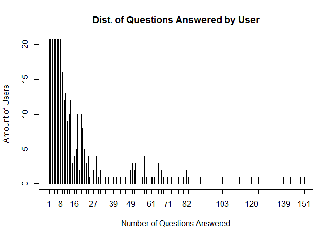

We can see the shape, and how it tapers off.

### What are the most common tags?

For this problem, I was able to count up how many times each tag was used in a question (a tag couldn’t be used more than once in a post). I excluded r, since it was used in every post, and I charted the top 24 tags, it is presented:

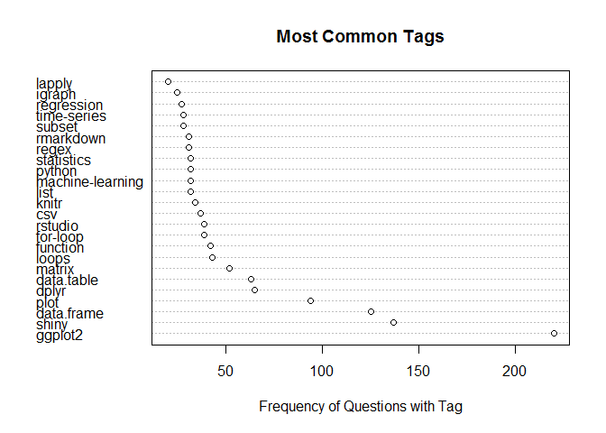

I used a shortcut and only sampled the first 2500 posts for tags, to save on computer intensity.

### How many questions involve XML, HTML or Web Scraping?

I found 1.28% of the posts, had a tag that was either XML, HTML, or Web Scraping.

# Code Appendix

```
library( XML)
library( RCurl)

html <- htmlParse("http://stackoverflow.com/questions/tagged/r?sort=newest&pagesize=50")

#usernames
usernames <- function( html){
  path<-"//div[@class = 'user-details']"
  nodes <- getNodeSet( html, path)
  return( sapply( strsplit( xmlSApply(nodes, xmlValue, trim = TRUE), "\r\n"), `[[`, 1))}

#when
timestmps <- function( html){
  path <- "//div[@class = 'user-action-time']/span/@title"
  nodes <- getNodeSet( html, path)
  times <- unlist(nodes)
  names( times) = NULL
  return( times)}

#title
titles <- function( html){
  path <- "//div[@class = 'summary']/h3/a[@class = 'question-hyperlink']/text()"
  nodes <- getNodeSet( html, path)
  return( xmlSApply( nodes, xmlValue))}

reps <- function( html){
  path <- "//div[@class = 'user-details']//span[@class = 'reputation-score']/text()"
  nodes <- getNodeSet( html, path)
  interject <- xmlSApply( nodes, xmlValue)
  path2 <- "//div[@class = 'user-details']"
  nodes2 <- getNodeSet(html, path2)
  ref <- sapply( strsplit( xmlSApply(nodes2, xmlValue, trim = TRUE), "\r\n"), function(p) length(p)>1)
  ref[which(ref == TRUE)] <- interject
  ref[which(ref == "FALSE")] <- NA
  return(ref)}

#views
views <- function( html){
  path <- "//div[@class = 'statscontainer']/div[starts-with(@class, 'views')]/@title"
  nodes <- getNodeSet( html, path)
```

[output cut: 131 more lines]

```

#How many questions involve XML, HTML, or Web Scraping?

length(grep("xml|html|web-scraping", master.tags, ignore.case=TRUE))/2500

#sad attempt to try and pull text and grep through
xmlSApply(rQAs$text, xmlValue)
xmlSApply( htmlParse(rQAs[1,6]), xmlValue)
xmlSApply( getNodeSet(xmlParse(rQAs[1,6]), "//text()"), xmlValue)
q.ind <- which(rQAs$type=="question")
involve <- sapply(1:10004, function(q){
  text <- xmlSApply( getNodeSet(xmlParse(rQAs[q.ind[q],6]), "//text()"), xmlValue)
  result <- grep("xml|html|web([ -])?scraping", text, ignore.case=TRUE)
  return(result>0)
})
```